# Activity Monitoring Data - Research

Nagesh

Monday 16 February 2015

```r
knitr::opts_chunk$set(fig.width=12, fig.height=8, fig.path='Figs/')
```

# Introduction

It is now possible to collect a large amount of data about personal movement using activity monitoring devices such as a Fitbit, Nike Fuelband, or Jawbone Up. These type of devices are part of the “quantified self” movement – a group of enthusiasts who take measurements about themselves regularly to improve their health, to find patterns in their behavior, or because they are tech geeks. But these data remain under-utilized both because the raw data are hard to obtain and there is a lack of statistical methods and software for processing and interpreting the data.

## Data collection

This assignment makes use of data from a personal activity monitoring device. This device collects data at 5 minute intervals through out the day. The data consists of two months of data from an anonymous individual collected during the months of October and November, 2012 and include the number of steps taken in 5 minute intervals each day.

## Assignment

We will do some research with this data and make it reproducible for others.

# Mean number of steps

First, we ignore all the `NA` values by using the `omit.NA()` function on the data frame created by reading the `activity.csv` file.

## Total number of steps per day

We sum the `steps` column in the data frame per day to arrive the total figure.

```r
library(dplyr)
summarise(group_by(stepsDf,date),stepCount=sum(steps))
```

```
## Source: local data frame [53 x 2]
##
##          date stepCount
## 1  2012-10-02       126
## 2  2012-10-03     11352
## 3  2012-10-04     12116
## 4  2012-10-05     13294
## 5  2012-10-06     15420
## 6  2012-10-07     11015
## 7  2012-10-09     12811
## 8  2012-10-10      9900
## 9  2012-10-11     10304
## 10 2012-10-12     17382
## 11 2012-10-13     12426
## 12 2012-10-14     15098
```

[output cut: 41 more lines]

To understand that frequency of step counts in a given a time interval, we plot a histogram for the step count as shown below.

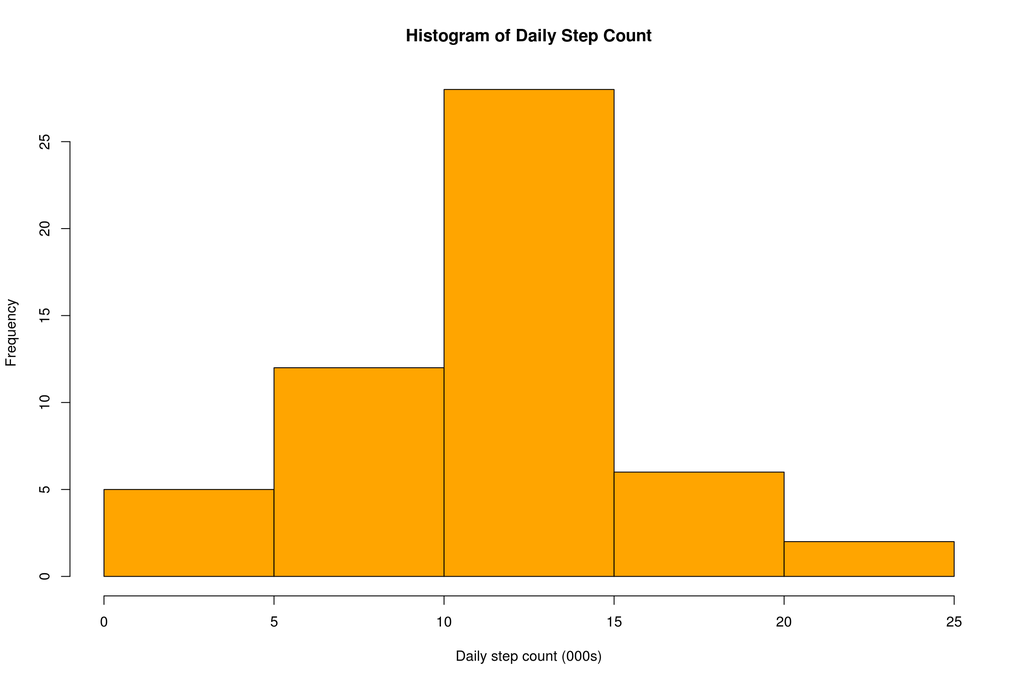

```r
stepCountDf<-summarise(group_by(stepsDf,date),
                       stepCount=sum(steps)/1000)
#
hist(stepCountDf$stepCount,
     main="Histogram of Daily Step Count",
     xlab="Daily step count (000s)",
     col="orange")
```

To look at the step counts on a daily basis, we plot a bar plot as shown below.

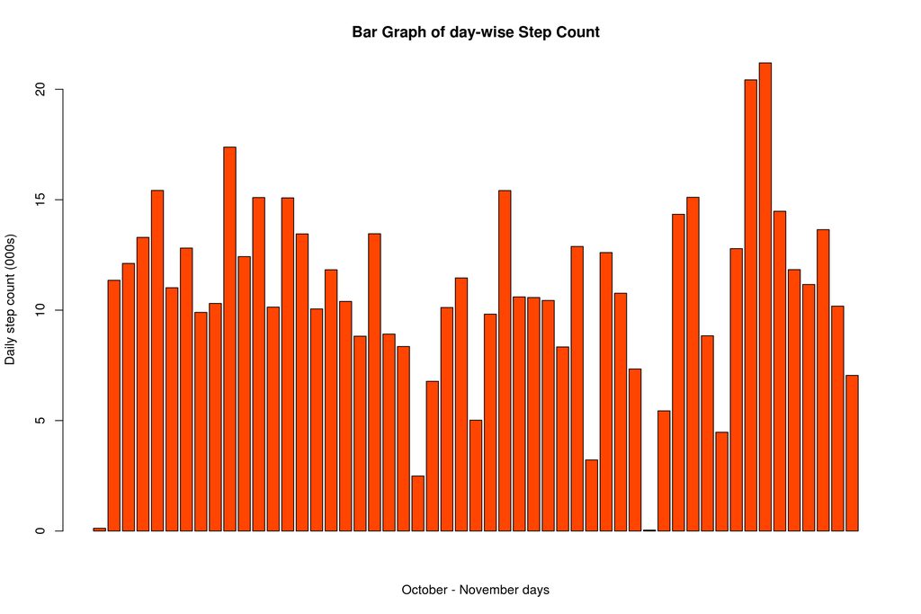

```r
barplot(stepCountDf$stepCount,
        main="Bar Graph of day-wise Step Count",
        xlab="October - November days",
        ylab="Daily step count (000s)",
        col="orangered1")
```

## Mean and median values of step count

The mean and median values of the step count are calculated and displayed as shown below:

```r
library(dplyr)
summarise(group_by(stepsDf,date),
          stepMean=mean(steps),
          stepMedian=median(steps))
```

```
## Source: local data frame [53 x 3]
##
##          date   stepMean stepMedian
## 1  2012-10-02  0.4375000          0
## 2  2012-10-03 39.4166667          0
## 3  2012-10-04 42.0694444          0
## 4  2012-10-05 46.1597222          0
## 5  2012-10-06 53.5416667          0
## 6  2012-10-07 38.2465278          0
## 7  2012-10-09 44.4826389          0
## 8  2012-10-10 34.3750000          0
## 9  2012-10-11 35.7777778          0
## 10 2012-10-12 60.3541667          0
## 11 2012-10-13 43.1458333          0
## 12 2012-10-14 52.4236111          0
```

[output cut: 41 more lines]

The values are plotted as shown below

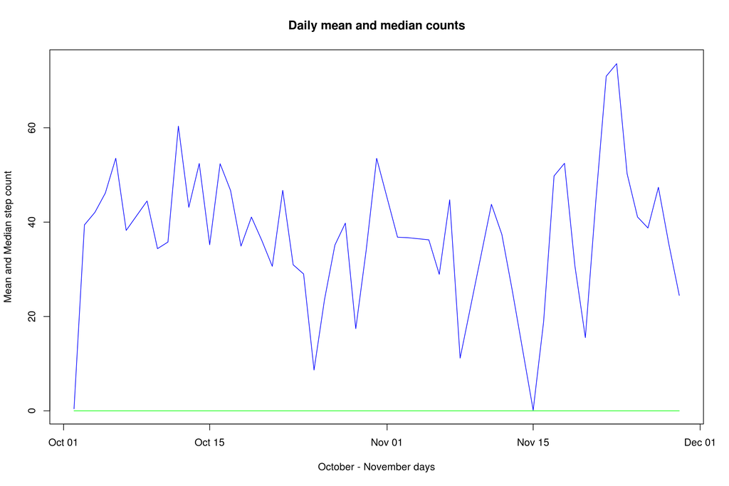

```r
stepStatDf<-summarise(group_by(stepsDf,date),
                      stepMean=mean(steps),
                      stepMedian=median(steps))
plot(stepStatDf$date,stepStatDf$stepMean,
     type="l",
     xlab="October - November days",
     ylab="Mean and Median step count",
     main="Daily mean and median counts",
     col="blue")
lines(stepStatDf$date,stepStatDf$stepMedian,
      type="l",
      col="green")
```

# Average daily pattern

## Mean step count based on intervals

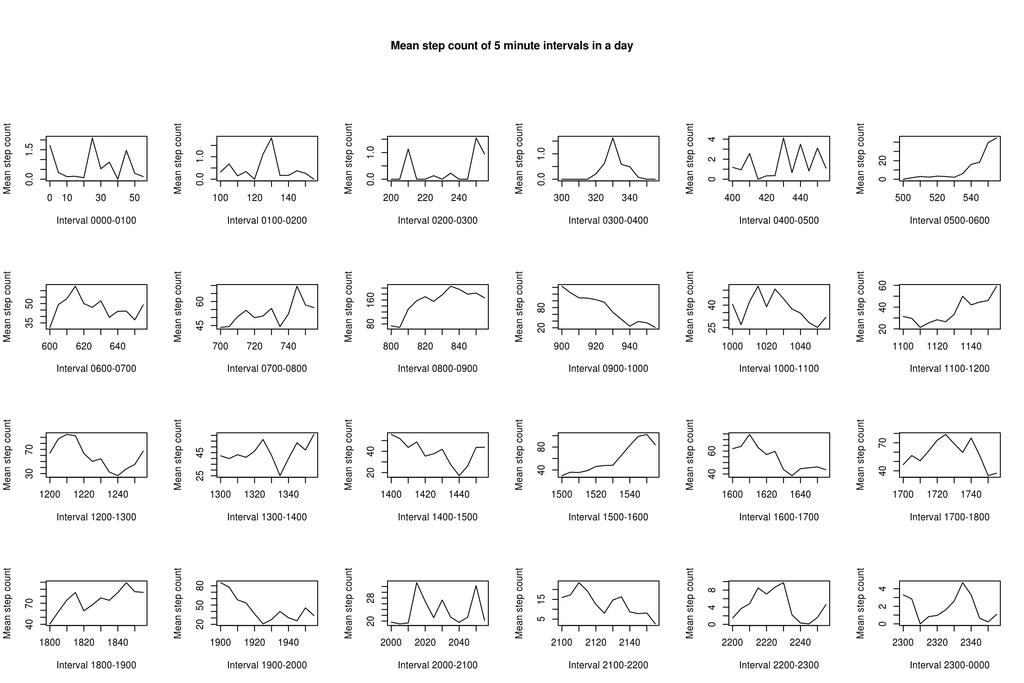

```r
intervalStepsDf<-summarise(group_by(stepsDf,interval),
                           stepCount=mean(steps))
intvlDf<-split(intervalStepsDf,
               rep(1:24,each=12))
par(mfrow=c(4,6),
    oma = c(0,0,8,0))
plot(intvlDf[[1]]$interval,intvlDf[[1]]$stepCount,
     type="l",
     xlab="Interval 0000-0100",
     ylab="Mean step count")
plot(intvlDf[[2]]$interval,intvlDf[[2]]$stepCount,
     type="l",
     xlab="Interval 0100-0200",
     ylab="Mean step count")
plot(intvlDf[[3]]$interval,intvlDf[[3]]$stepCount,
     type="l",
     xlab="Interval 0200-0300",
     ylab="Mean step count")
plot(intvlDf[[4]]$interval,intvlDf[[4]]$stepCount,
     type="l",
     xlab="Interval 0300-0400",
     ylab="Mean step count")
plot(intvlDf[[5]]$interval,intvlDf[[5]]$stepCount,
     type="l",
     xlab="Interval 0400-0500",
     ylab="Mean step count")
plot(intvlDf[[6]]$interval,intvlDf[[6]]$stepCount,
     type="l",
     xlab="Interval 0500-0600",
     ylab="Mean step count")
plot(intvlDf[[7]]$interval,intvlDf[[7]]$stepCount,
     type="l",
     xlab="Interval 0600-0700",
     ylab="Mean step count")
plot(intvlDf[[8]]$interval,intvlDf[[8]]$stepCount,
     type="l",
     xlab="Interval 0700-0800",
     ylab="Mean step count")
plot(intvlDf[[9]]$interval,intvlDf[[9]]$stepCount,
     type="l",
     xlab="Interval 0800-0900",
     ylab="Mean step count")
plot(intvlDf[[10]]$interval,intvlDf[[10]]$stepCount,
     type="l",
     xlab="Interval 0900-1000",
     ylab="Mean step count")
plot(intvlDf[[11]]$interval,intvlDf[[11]]$stepCount,
     type="l",
     xlab="Interval 1000-1100",
     ylab="Mean step count")
plot(intvlDf[[12]]$interval,intvlDf[[12]]$stepCount,
     type="l",
     xlab="Interval 1100-1200",
     ylab="Mean step count")
plot(intvlDf[[13]]$interval,intvlDf[[13]]$stepCount,
     type="l",
     xlab="Interval 1200-1300",
     ylab="Mean step count")
plot(intvlDf[[14]]$interval,intvlDf[[14]]$stepCount,
     type="l",
     xlab="Interval 1300-1400",
     ylab="Mean step count")
plot(intvlDf[[15]]$interval,intvlDf[[15]]$stepCount,
     type="l",
     xlab="Interval 1400-1500",
     ylab="Mean step count")
plot(intvlDf[[16]]$interval,intvlDf[[16]]$stepCount,
     type="l",
     xlab="Interval 1500-1600",
     ylab="Mean step count")
plot(intvlDf[[17]]$interval,intvlDf[[17]]$stepCount,
     type="l",
     xlab="Interval 1600-1700",
     ylab="Mean step count")
plot(intvlDf[[18]]$interval,intvlDf[[18]]$stepCount,
     type="l",
     xlab="Interval 1700-1800",
     ylab="Mean step count")
plot(intvlDf[[19]]$interval,intvlDf[[19]]$stepCount,
     type="l",
     xlab="Interval 1800-1900",
     ylab="Mean step count")
plot(intvlDf[[20]]$interval,intvlDf[[20]]$stepCount,
     type="l",
     xlab="Interval 1900-2000",
     ylab="Mean step count")
plot(intvlDf[[21]]$interval,intvlDf[[21]]$stepCount,
     type="l",
     xlab="Interval 2000-2100",
     ylab="Mean step count")
plot(intvlDf[[22]]$interval,intvlDf[[22]]$stepCount,
     type="l",
     xlab="Interval 2100-2200",
     ylab="Mean step count")
plot(intvlDf[[23]]$interval,intvlDf[[23]]$stepCount,
     type="l",
     xlab="Interval 2200-2300",
     ylab="Mean step count")
plot(intvlDf[[24]]$interval,intvlDf[[24]]$stepCount,
     type="l",
     xlab="Interval 2300-0000",
     ylab="Mean step count")
title("Mean step count of 5 minute intervals in a day",outer="TRUE")
```

# Imputing missing values

## Count of missing values

There are a total of 2304 missing values in the activity dataset. As a percentage, the missing values is 13.11% of the whole.

## Imputed missing values

To impute the missing values, we will calculate the average step count on a per interval basis across all days of observation. This average value will be used to replace the `NA` values in the original data set corresponding to the same interval. Here are the steps to generate a new data frame using this strategy.

```r
# ACT is the data frame created by reading the CSV file of activity.
# Not shown here for sake of brevity.
misSteps<-filter(ACT,is.na(steps))
xDf<-merge(misSteps,stepsMeanDf,
           by.x="interval",
           by.y="interval")
x1Df<-mutate(xDf,
             steps=meanSteps)
y1Df<-data.frame(x1Df$steps,
                x1Df$date,
                x1Df$interval)
names(y1Df)<-c("steps","date","interval")
# The missing values from the activity data frame are now populated with the mean values
# into y1Df
y2Df<-data.frame(as.numeric(stepsDf$steps),
                 stepsDf$date,
                 stepsDf$interval)
names(y2Df)<-c("steps","date","interval")
# The data frame without NA values is y2Df
zDf<-rbind(y1Df,y2Df)
newDf<-arrange(zDf,
               date,interval)
# Arranging after merge, we have the final dataset
head(newDf)
```

```
##       steps       date interval
## 1 1.7169811 2012-10-01        0
## 2 0.3396226 2012-10-01        5
## 3 0.1320755 2012-10-01       10
## 4 0.1509434 2012-10-01       15
## 5 0.0754717 2012-10-01       20
## 6 2.0943396 2012-10-01       25
```

Here is the histogram with the imputed values.

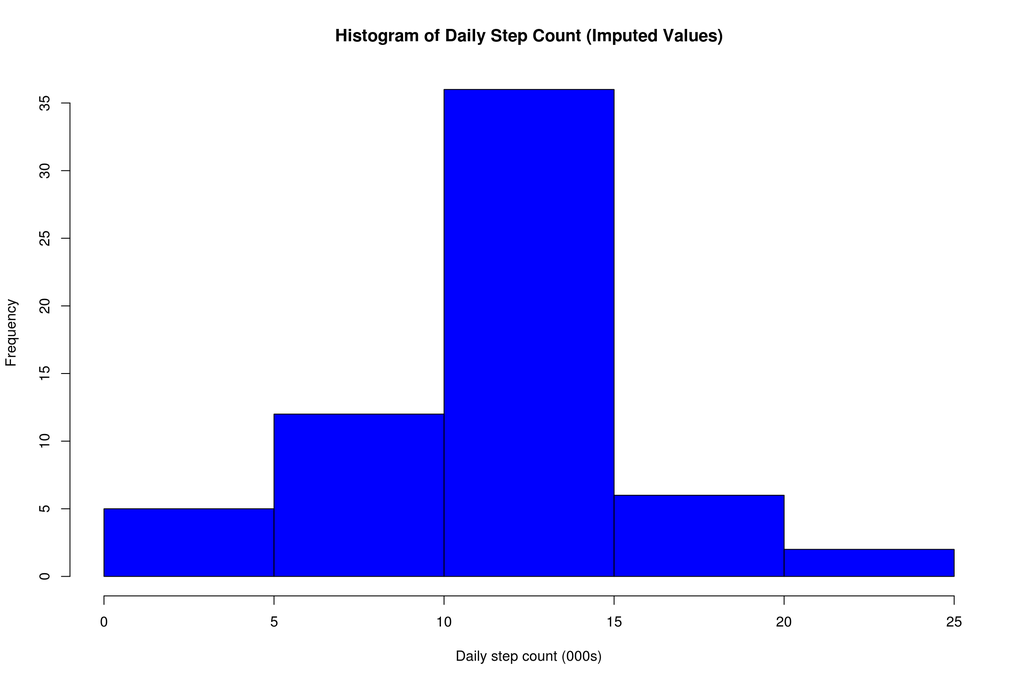

```r
sumNewDf<-summarise(group_by(newDf,date),
                    totalCount=sum(steps)/1000)
hist(sumNewDf$totalCount,
     main="Histogram of Daily Step Count (Imputed Values)",
     xlab="Daily step count (000s)",
     col="blue")
```

The mean and median for the imputed data set are shown here:

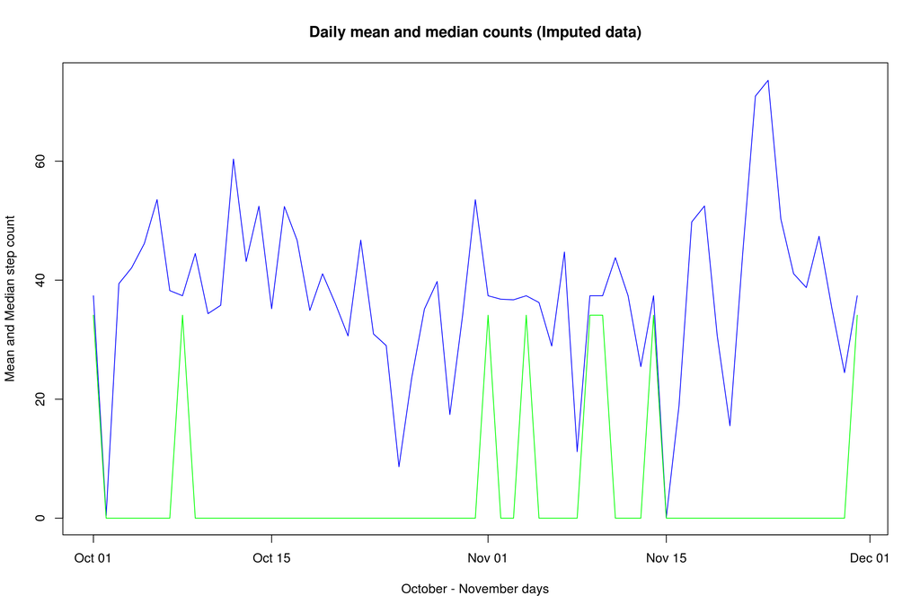

```r
staDf<-summarise(group_by(newDf,date),
                 stepMean=mean(steps),
                 stepMedian=median(steps))
plot(staDf$date,staDf$stepMean,
     type="l",
     xlab="October - November days",
     ylab="Mean and Median step count",
     main="Daily mean and median counts (Imputed data)",
     col="blue")
lines(staDf$date,staDf$stepMedian,
      type="l",
      col="green")
```

## Result of imputing the data

After imputing the data, the histogram and the mean values do not show much deviation. However, the median values now shows spikes for some days.

# Weekday and weekend patterns

We will now explore the data on the basis of step counts on week days and week ends.

## Day classification

To classify the days of observation, we use the `weekdays()` function and create a new data frame with the name of the weekday included.

```r
d1<-mutate(newDf,
              day=weekdays(date))
daySumm<-summarise(group_by(d1,day,interval),
                   stepMean=mean(steps))
head(daySumm)
```

```
## Source: local data frame [6 x 3]
## Groups: day
##
##      day interval   stepMean
## 1 Friday        0 0.38155136
## 2 Friday        5 0.07547170
## 3 Friday       10 0.02935010
## 4 Friday       15 0.03354298
## 5 Friday       20 0.01677149
## 6 Friday       25 0.46540881
```

To plot the step count and see the spread across days of week, we will use the `ggplot2` library as shown below.

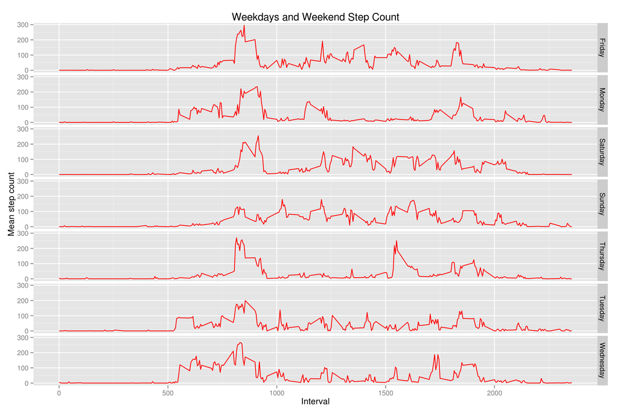

```r
library(ggplot2)
p <- ggplot(daySumm,
            aes(x=interval,
                y=stepMean))
p <- p + geom_line(colour="red")
p <- p + xlab("Interval")
p <- p + ylab("Mean step count")
p <- p + ggtitle("Weekdays and Weekend Step Count")
p + facet_grid(day ~ .)
```

For a more condensed plot, we will first get counts split across two broad categories - weekdays and weekends.

```r
newDf<-mutate(newDf,
              day=weekdays(date))
wEnd<-newDf %>%
  filter(day=="Saturday" | day=="Sunday") %>%
  mutate(day="WEEKEND")
wDay<-newDf %>%
  filter(day!="Saturday" & day!="Sunday") %>%
  mutate(day="WEEKDAY")
d1<-rbind(wDay,wEnd)
d2<-summarise(group_by(d1,date),
              stepMean=mean(steps))
days<-merge(d2,d1,
          by.x="date",
          by.y="date")
days<-arrange(days,date,interval)
days<-mutate(days,
             day=as.factor(day))
```

Here is a plot with the factors set to `WEEKDAY` and `WEEKEND`

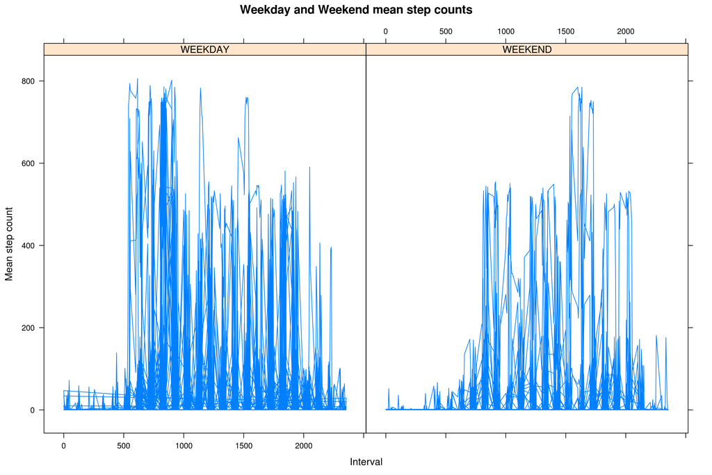

```r
library(lattice)
xyplot(days$steps ~ days$interval | days$day,
       type="l",
       xlab="Interval",
       ylab="Mean step count",
       main="Weekday and Weekend mean step counts",
       layout=c(2,1))
```